# automatization_notebook_04

2024-10-13

# Чтение данных

В вашем варианте нужно использовать датасет healthcare-dataset-stroke-data.

```r
data <- read.csv('./data/raw/healthcare-dataset-stroke-data.csv', sep = ',', header = TRUE)
#пусть id из первого столбца будут названиями строк:
rownames(data) <- data$id
data <- data[,-1]
head(data)
```

|  | gender | age | hypertension | heart_disease | ever_married | work_type | Residence_type | avg_glucose_level | bmi | smoking_status | stroke |
| --- | --- | --- | --- | --- | --- | --- | --- | --- | --- | --- | --- |
| 9046 | Male | 67 | 0 | 1 | Yes | Private | Urban | 228.69 | 36.6 | formerly smoked | 1 |
| 51676 | Female | 61 | 0 | 0 | Yes | Self-employed | Rural | 202.21 | N/A | never smoked | 1 |
| 31112 | Male | 80 | 0 | 1 | Yes | Private | Rural | 105.92 | 32.5 | never smoked | 1 |
| 60182 | Female | 49 | 0 | 0 | Yes | Private | Urban | 171.23 | 34.4 | smokes | 1 |
| 1665 | Female | 79 | 1 | 0 | Yes | Self-employed | Rural | 174.12 | 24 | never smoked | 1 |
| 56669 | Male | 81 | 0 | 0 | Yes | Private | Urban | 186.21 | 29 | formerly smoked | 1 |

# Выведите общее описание данных

```r
dim(data) #сколько строк, сколько столбцов
```

```
## [1] 5110   11
```

```r
str(data)
```

```
## 'data.frame':    5110 obs. of  11 variables:
##  $ gender           : chr  "Male" "Female" "Male" "Female" ...
##  $ age              : num  67 61 80 49 79 81 74 69 59 78 ...
##  $ hypertension     : int  0 0 0 0 1 0 1 0 0 0 ...
##  $ heart_disease    : int  1 0 1 0 0 0 1 0 0 0 ...
##  $ ever_married     : chr  "Yes" "Yes" "Yes" "Yes" ...
##  $ work_type        : chr  "Private" "Self-employed" "Private" "Private" ...
##  $ Residence_type   : chr  "Urban" "Rural" "Rural" "Urban" ...
##  $ avg_glucose_level: num  229 202 106 171 174 ...
##  $ bmi              : chr  "36.6" "N/A" "32.5" "34.4" ...
##  $ smoking_status   : chr  "formerly smoked" "never smoked" "never smoked" "smokes" ...
##  $ stroke           : int  1 1 1 1 1 1 1 1 1 1 ...
```

```r
summary(data)
```

```
##     gender               age         hypertension     heart_disease
##  Length:5110        Min.   : 0.08   Min.   :0.00000   Min.   :0.00000
##  Class :character   1st Qu.:25.00   1st Qu.:0.00000   1st Qu.:0.00000
##  Mode  :character   Median :45.00   Median :0.00000   Median :0.00000
##                     Mean   :43.23   Mean   :0.09746   Mean   :0.05401
##                     3rd Qu.:61.00   3rd Qu.:0.00000   3rd Qu.:0.00000
##                     Max.   :82.00   Max.   :1.00000   Max.   :1.00000
##  ever_married        work_type         Residence_type     avg_glucose_level
##  Length:5110        Length:5110        Length:5110        Min.   : 55.12
##  Class :character   Class :character   Class :character   1st Qu.: 77.25
##  Mode  :character   Mode  :character   Mode  :character   Median : 91.89
##                                                           Mean   :106.15
##                                                           3rd Qu.:114.09
##                                                           Max.   :271.74
##      bmi            smoking_status         stroke
##  Length:5110        Length:5110        Min.   :0.00000
##  Class :character   Class :character   1st Qu.:0.00000
##  Mode  :character   Mode  :character   Median :0.00000
##                                        Mean   :0.04873
##                                        3rd Qu.:0.00000
##                                        Max.   :1.00000
```

# Очистка данных: начало

1. Уберите переменные, в которых пропущенных значений больше 20% или уберите субъектов со слишком большим количеством пропущенных значений. Или совместите оба варианта. Напишите обоснование, почему вы выбрали тот или иной вариант.

Сначала все-таки приведем данные к нужному типу, а потом займемся пропусками:

```r
data$gender <- as.factor(data$gender)
data$age <- as.integer(data$age)
data$hypertension <- as.factor(data$hypertension)
data$heart_disease <- as.factor(data$heart_disease)
data$ever_married <- as.factor(data$ever_married)
data$work_type <- as.factor(data$work_type)
data$Residence_type <- as.factor(data$Residence_type)
data$avg_glucose_level <- as.numeric(data$avg_glucose_level)
data$bmi <- as.numeric(data$bmi)
data$smoking_status <- as.factor(data$smoking_status)
data$stroke <- as.factor(data$stroke)
```

# Сколько всего переменных с пропущенными значениями в данных и сколько пропущенных точек в каждой такой переменной?

```r
str(data)
```

```
## 'data.frame':    5110 obs. of  11 variables:
##  $ gender           : Factor w/ 3 levels "Female","Male",..: 2 1 2 1 1 2 2 1 1 1 ...
##  $ age              : int  67 61 80 49 79 81 74 69 59 78 ...
##  $ hypertension     : Factor w/ 2 levels "0","1": 1 1 1 1 2 1 2 1 1 1 ...
##  $ heart_disease    : Factor w/ 2 levels "0","1": 2 1 2 1 1 1 2 1 1 1 ...
##  $ ever_married     : Factor w/ 2 levels "No","Yes": 2 2 2 2 2 2 2 1 2 2 ...
##  $ work_type        : Factor w/ 5 levels "children","Govt_job",..: 4 5 4 4 5 4 4 4 4 4 ...
##  $ Residence_type   : Factor w/ 2 levels "Rural","Urban": 2 1 1 2 1 2 1 2 1 2 ...
##  $ avg_glucose_level: num  229 202 106 171 174 ...
##  $ bmi              : num  36.6 NA 32.5 34.4 24 29 27.4 22.8 NA 24.2 ...
##  $ smoking_status   : Factor w/ 4 levels "formerly smoked",..: 1 2 2 3 2 1 2 2 4 4 ...
##  $ stroke           : Factor w/ 2 levels "0","1": 2 2 2 2 2 2 2 2 2 2 ...
```

```r
summary(data)
```

```
##     gender          age        hypertension heart_disease ever_married
##  Female:2994   Min.   : 0.00   0:4612       0:4834        No :1757
##  Male  :2115   1st Qu.:25.00   1: 498       1: 276        Yes:3353
##  Other :   1   Median :45.00
##                Mean   :43.22
##                3rd Qu.:61.00
##                Max.   :82.00
##
##          work_type    Residence_type avg_glucose_level      bmi
##  children     : 687   Rural:2514     Min.   : 55.12    Min.   :10.30
##  Govt_job     : 657   Urban:2596     1st Qu.: 77.25    1st Qu.:23.50
##  Never_worked :  22                  Median : 91.89    Median :28.10
##  Private      :2925                  Mean   :106.15    Mean   :28.89
##  Self-employed: 819                  3rd Qu.:114.09    3rd Qu.:33.10
##                                      Max.   :271.74    Max.   :97.60
##                                                        NA's   :201
##          smoking_status stroke
##  formerly smoked: 885   0:4861
##  never smoked   :1892   1: 249
##  smokes         : 789
##  Unknown        :1544
##
##
##
```

Мы видим, что:

- в столбце gender имеется один случай с gender=Other,
- в столбце bmi есть **201 пропуск** (NA), что составляет 3.93% от общего числа субъектов,
- в столбце smoking_status есть **1544 пропуска** (Unknown), что составляет 30.22% от общего числа субъектов.

Теперь посмотрим, сколько субъектов имеют пропущенные значения одновременно для bmi и smoking_status.

```r
dim(data %>%
  filter(is.na(bmi) & smoking_status == "Unknown"))[1]
```

```
## [1] 61
```

Итак, субъектов с пропусками в 2 столбцах имеется **61 человек**, что составляет 1.19% от общего числа субъектов, что очень мало.

**Обоснование дальнейшей очистки:** Доля субъектов с пропусками 2 столбцах очень мала и удаление таких наблюдений не приведет к сильной потере данных. Также стоит удалить субъекта с gender=Other, так как 1 наблюдения в любом случае не будет достаточно для получения статистически значимых выводов об особенностях субъектов с данным полом. Что касается переменных с пропусками (bmi, smoking_status), стоит удалить переменную smoking_status, так как доля пропусков в ней достаточно велика (больше 20%), и если удалить субъектов с пропуском smoking_status, субъектов останется намного меньше. Доля пропусков в переменной bmi мала и не стоит удалять ее, ведь она может оказаться важным фактором. Итак, нужно сначала удалить переменную smoking_status, а потом субъектов со значением пола Other и пропуском в индексе масса тела.

# Очистка данных: продолжение

```r
data2 <- data
data2$smoking_status <- NULL
data2 <- data2 %>%
  filter(gender != "Other" & !is.na(bmi))
data2 <- droplevels(data2)
```

# Сколько осталось переменных?

```r
dim(data2)[2]
```

```
## [1] 10
```

# Сколько осталось случаев?

```r
dim(data2)[1]
```

```
## [1] 4908
```

2. Переименуйте переменные в человекочитаемый вид (что делать с пробелами в названиях?);

Пробелы в названиях имелись только для значений переменной smoking_status, которая была удалена. Осталось переименовать одну из колонок для большей однотипности:

```r
names(data2)[names(data2) == 'Residence_type'] <- 'residence_type'
```

3. В соответствии с описанием данных приведите переменные к нужному типу (numeric или factor); (было выполнено выше)
4. Отсортируйте данные по возрасту по убыванию;

```r
data3 <- data2 %>%
  arrange(desc(age))
```

5. Сохраните в файл outliers.csv субъектов, которые являются выбросами (например, по правилу трёх сигм) — это необязательное задание со звёздочкой;

Создадим датасеты с выбросами отдельно по age, avg_glucose_level и bmi, и посмотрим число оставшихся субъектов:

```r
data3_outliers_by_age <- data3 %>%
  filter(age >= mean(data3$age) + 3*sd(data3$age) | age <= mean(data3$age) - 3*sd(data3$age))

dim(data3_outliers_by_age)[1]
```

```
## [1] 0
```

```r
data3_outliers_by_avg_glucose_level <- data3 %>%
  filter(avg_glucose_level >= mean(data3$avg_glucose_level) + 3*sd(data3$avg_glucose_level) | avg_glucose_level <= mean(data3$avg_glucose_level) - 3*sd(data3$avg_glucose_level))

dim(data3_outliers_by_avg_glucose_level)[1]
```

```
## [1] 60
```

```r
data3_outliers_by_bmi <- data3 %>%
  filter(bmi >= mean(data3$bmi) + 3*sd(data3$bmi) | bmi <= mean(data3$bmi) - 3*sd(data3$bmi))

dim(data3_outliers_by_bmi)[1]
```

```
## [1] 58
```

Теперь соединим датасеты и удалим у итогового строки-дубликаты:

```r
data3_outliers <- rbind(data3_outliers_by_avg_glucose_level, data3_outliers_by_bmi)
sum(duplicated(data3_outliers))
```

```
## [1] 1
```

```r
data3_outliers <- data3_outliers[!duplicated(data3_outliers), ]
```

```r
write.csv(data3_outliers, file = 'outliers.csv')
```

6. Присвойте получившийся датасет переменной “cleaned_data”.

```r
cleaned_data <- data3
```

# Есть ли в данных идентичные строки?

```r
sum(duplicated(data))
```

```
## [1] 0
```

```r
sum(duplicated(cleaned_data))
```

```
## [1] 0
```

Идентичных строк нет ни в исходном датасете, не в конечном.

# Описательные статистики

## Количественные переменные

1. Рассчитайте для всех количественных переменных для каждой группы (stroke):

1.1) Количество значений;

Рассчитаем отдельно для исходного датасета, и для конечного (почищенного).

```r
rows_count <- function(df) {
  number_of_rows <- df %>%
    group_by(stroke) %>%
    count()
  return(number_of_rows)
}

rows_count(data)
```

| stroke | n |
| --- | --- |
| 0 | 4861 |
| 1 | 249 |

```r
rows_count(cleaned_data)
```

| stroke | n |
| --- | --- |
| 0 | 4699 |
| 1 | 209 |

1.2) Количество пропущенных значений;

Рассчитаем отдельно для исходного датасета, и для конечного (почищенного).

```r
na_count <- function(df, colname) {
  number_of_na <- df %>%
    group_by(stroke) %>%
    filter(is.na({{colname}})) %>%
    count()
  return(number_of_na)
}

na_count(data, age)
```

| stroke | n |
| --- | --- |

```r
na_count(data, avg_glucose_level)
```

| stroke | n |
| --- | --- |

```r
na_count(data, bmi)
```

| stroke | n |
| --- | --- |
| 0 | 161 |
| 1 | 40 |

```r
na_count(cleaned_data, age)
```

| stroke | n |
| --- | --- |

```r
na_count(cleaned_data, avg_glucose_level)
```

| stroke | n |
| --- | --- |

```r
na_count(cleaned_data, bmi)
```

| stroke | n |
| --- | --- |

Пропущенные значения есть только для bmi до очистки. После очистки пропущенных значений нет - она прошла успешно.

1.3) Среднее;

```r
mean_calc <- function(df, colname) {
  means <- df %>%
    group_by(stroke) %>%
    summarise(mean = mean({{colname}}))
  return(means)
}

mean_calc(cleaned_data, age)
```

| stroke | mean |
| --- | --- |
| 0 | 41.75207 |
| 1 | 67.71292 |

```r
mean_calc(cleaned_data, avg_glucose_level)
```

| stroke | mean |
| --- | --- |
| 0 | 103.9954 |
| 1 | 134.5714 |

```r
mean_calc(cleaned_data, bmi)
```

| stroke | mean |
| --- | --- |
| 0 | 28.82443 |
| 1 | 30.47129 |

1.4) Медиану;

```r
median_calc <- function(df, colname) {
  medians <- df %>%
    group_by(stroke) %>%
    summarise(median = median({{colname}}))
  return(medians)
}

median_calc(cleaned_data, age)
```

| stroke | median |
| --- | --- |
| 0 | 43 |
| 1 | 70 |

```r
median_calc(cleaned_data, avg_glucose_level)
```

| stroke | median |
| --- | --- |
| 0 | 91.21 |
| 1 | 106.58 |

```r
median_calc(cleaned_data, bmi)
```

| stroke | median |
| --- | --- |
| 0 | 28.0 |
| 1 | 29.7 |

1.5) Стандартное отклонение;

```r
sd_calc <- function(df, colname) {
  sds <- df %>%
    group_by(stroke) %>%
    summarise(sd = sd({{colname}}))
  return(sds)
}

sd_calc(cleaned_data, age)
```

| stroke | sd |
| --- | --- |
| 0 | 22.29081 |
| 1 | 12.40285 |

```r
sd_calc(cleaned_data, avg_glucose_level)
```

| stroke | sd |
| --- | --- |
| 0 | 42.99855 |
| 1 | 62.46205 |

```r
sd_calc(cleaned_data, bmi)
```

| stroke | sd |
| --- | --- |
| 0 | 7.908573 |
| 1 | 6.329452 |

1.6) 25% квантиль и 75% квантиль;

```r
quantile_calc <- function(df, colname) {
  quantiles <- df %>%
    group_by(stroke) %>%
    reframe(quantile = quantile({{colname}}, probs = c(0.25, 0.75)))
  return(quantiles)
}

quantile_calc(cleaned_data, age)
```

| stroke | quantile |
| --- | --- |
| 0 | 24 |
| 0 | 59 |
| 1 | 58 |
| 1 | 78 |

```r
quantile_calc(cleaned_data, avg_glucose_level)
```

| stroke | quantile |
| --- | --- |
| 0 | 76.885 |
| 0 | 112.420 |
| 1 | 80.430 |
| 1 | 196.920 |

```r
quantile_calc(cleaned_data, bmi)
```

| stroke | quantile |
| --- | --- |
| 0 | 23.4 |
| 0 | 33.1 |
| 1 | 26.4 |
| 1 | 33.7 |

1.7) Интерквартильный размах;

```r
IQR_calc <- function(df, colname) {
  IQRs <- df %>%
    group_by(stroke) %>%
    reframe(IQR = IQR({{colname}}))
  return(IQRs)
}

IQR_calc(cleaned_data, age)
```

| stroke | IQR |
| --- | --- |
| 0 | 35 |
| 1 | 20 |

```r
IQR_calc(cleaned_data, avg_glucose_level)
```

| stroke | IQR |
| --- | --- |
| 0 | 35.535 |
| 1 | 116.490 |

```r
IQR_calc(cleaned_data, bmi)
```

| stroke | IQR |
| --- | --- |
| 0 | 9.7 |
| 1 | 7.3 |

1.8) Минимум;

```r
min_calc <- function(df, colname) {
  mins <- df %>%
    group_by(stroke) %>%
    summarise(min = min({{colname}}))
  return(mins)
}

min_calc(cleaned_data, age)
```

| stroke | min |
| --- | --- |
| 0 | 0 |
| 1 | 14 |

```r
min_calc(cleaned_data, avg_glucose_level)
```

| stroke | min |
| --- | --- |
| 0 | 55.12 |
| 1 | 56.11 |

```r
min_calc(cleaned_data, bmi)
```

| stroke | min |
| --- | --- |
| 0 | 10.3 |
| 1 | 16.9 |

1.9) Максимум;

```r
max_calc <- function(df, colname) {
  maxs <- df %>%
    group_by(stroke) %>%
    summarise(max = max({{colname}}))
  return(maxs)
}

max_calc(cleaned_data, age)
```

| stroke | max |
| --- | --- |
| 0 | 82 |
| 1 | 82 |

```r
max_calc(cleaned_data, avg_glucose_level)
```

| stroke | max |
| --- | --- |
| 0 | 267.76 |
| 1 | 271.74 |

```r
max_calc(cleaned_data, bmi)
```

| stroke | max |
| --- | --- |
| 0 | 97.6 |
| 1 | 56.6 |

1.10) 95% ДИ для среднего - задание со звёздочкой.

```r
confint_calc <- function(df, colname) {
  confints <- df %>%
    group_by(stroke) %>%
    reframe(confint = t.test({{colname}})$conf.int)
  return(confints)
}

confint_calc(cleaned_data, age)
```

| stroke | confint |
| --- | --- |
| 0 | 41.11457 |
| 0 | 42.38958 |
| 1 | 66.02158 |
| 1 | 69.40426 |

```r
confint_calc(cleaned_data, avg_glucose_level)
```

| stroke | confint |
| --- | --- |
| 0 | 102.7656 |
| 0 | 105.2251 |
| 1 | 126.0536 |
| 1 | 143.0891 |

```r
confint_calc(cleaned_data, bmi)
```

| stroke | confint |
| --- | --- |
| 0 | 28.59825 |
| 0 | 29.05061 |
| 1 | 29.60816 |
| 1 | 31.33442 |

## Категориальные переменные

1. Рассчитайте для всех категориальных переменных для каждой группы (stroke):

1.1) Абсолютное количество; Рассчитаем отдельно для исходного датасета, и для конечного (почищенного).

```r
rows_types_count <- function(df, colname) {
  number_of_rows_types <- df %>%
    group_by(stroke, {{colname}}) %>%
    count()
  return(number_of_rows_types)
}

print(rows_types_count(data, gender))
```

```
## # A tibble: 5 × 3
## # Groups:   stroke, gender [5]
##   stroke gender     n
##   <fct>  <fct>  <int>
## 1 0      Female  2853
## 2 0      Male    2007
## 3 0      Other      1
## 4 1      Female   141
## 5 1      Male     108
```

```r
rows_types_count(data, hypertension)
```

| stroke | hypertension | n |
| --- | --- | --- |
| 0 | 0 | 4429 |
| 0 | 1 | 432 |
| 1 | 0 | 183 |
| 1 | 1 | 66 |

```r
rows_types_count(data, heart_disease)
```

| stroke | heart_disease | n |
| --- | --- | --- |
| 0 | 0 | 4632 |
| 0 | 1 | 229 |
| 1 | 0 | 202 |
| 1 | 1 | 47 |

```r
rows_types_count(data, ever_married)
```

| stroke | ever_married | n |
| --- | --- | --- |
| 0 | No | 1728 |
| 0 | Yes | 3133 |
| 1 | No | 29 |
| 1 | Yes | 220 |

```r
rows_types_count(data, work_type)
```

| stroke | work_type | n |
| --- | --- | --- |
| 0 | children | 685 |
| 0 | Govt_job | 624 |
| 0 | Never_worked | 22 |
| 0 | Private | 2776 |
| 0 | Self-employed | 754 |
| 1 | children | 2 |
| 1 | Govt_job | 33 |
| 1 | Private | 149 |
| 1 | Self-employed | 65 |

```r
rows_types_count(data, Residence_type)
```

| stroke | Residence_type | n |
| --- | --- | --- |
| 0 | Rural | 2400 |
| 0 | Urban | 2461 |
| 1 | Rural | 114 |
| 1 | Urban | 135 |

```r
rows_types_count(data, smoking_status)
```

| stroke | smoking_status | n |
| --- | --- | --- |
| 0 | formerly smoked | 815 |
| 0 | never smoked | 1802 |
| 0 | smokes | 747 |
| 0 | Unknown | 1497 |
| 1 | formerly smoked | 70 |
| 1 | never smoked | 90 |
| 1 | smokes | 42 |
| 1 | Unknown | 47 |

```r
rows_types_count(cleaned_data, gender)
```

| stroke | gender | n |
| --- | --- | --- |
| 0 | Female | 2777 |
| 0 | Male | 1922 |
| 1 | Female | 120 |
| 1 | Male | 89 |

```r
rows_types_count(cleaned_data, hypertension)
```

| stroke | hypertension | n |
| --- | --- | --- |
| 0 | 0 | 4308 |
| 0 | 1 | 391 |
| 1 | 0 | 149 |
| 1 | 1 | 60 |

```r
rows_types_count(cleaned_data, heart_disease)
```

| stroke | heart_disease | n |
| --- | --- | --- |
| 0 | 0 | 4496 |
| 0 | 1 | 203 |
| 1 | 0 | 169 |
| 1 | 1 | 40 |

```r
rows_types_count(cleaned_data, ever_married)
```

| stroke | ever_married | n |
| --- | --- | --- |
| 0 | No | 1681 |
| 0 | Yes | 3018 |
| 1 | No | 23 |
| 1 | Yes | 186 |

```r
rows_types_count(cleaned_data, work_type)
```

| stroke | work_type | n |
| --- | --- | --- |
| 0 | children | 670 |
| 0 | Govt_job | 602 |
| 0 | Never_worked | 22 |
| 0 | Private | 2683 |
| 0 | Self-employed | 722 |
| 1 | children | 1 |
| 1 | Govt_job | 28 |
| 1 | Private | 127 |
| 1 | Self-employed | 53 |

```r
rows_types_count(cleaned_data, residence_type)
```

| stroke | residence_type | n |
| --- | --- | --- |
| 0 | Rural | 2318 |
| 0 | Urban | 2381 |
| 1 | Rural | 100 |
| 1 | Urban | 109 |

1.2) Относительное количество внутри группы;

```r
rows_types_proportion <- function(df, colname) {
  proportion_of_rows_types <- df %>%
    group_by(stroke, {{colname}}) %>%
    summarise(n=n()) %>%
    mutate(proportion = n/sum(n))
  return(proportion_of_rows_types)
}

print(rows_types_proportion(data, gender))
```

```
## # A tibble: 5 × 4
## # Groups:   stroke [2]
##   stroke gender     n proportion
##   <fct>  <fct>  <int>      <dbl>
## 1 0      Female  2853   0.587
## 2 0      Male    2007   0.413
## 3 0      Other      1   0.000206
## 4 1      Female   141   0.566
## 5 1      Male     108   0.434
```

```r
rows_types_proportion(data, hypertension)
```

| stroke | hypertension | n | proportion |
| --- | --- | --- | --- |
| 0 | 0 | 4429 | 0.9111294 |
| 0 | 1 | 432 | 0.0888706 |
| 1 | 0 | 183 | 0.7349398 |
| 1 | 1 | 66 | 0.2650602 |

```r
rows_types_proportion(data, heart_disease)
```

| stroke | heart_disease | n | proportion |
| --- | --- | --- | --- |
| 0 | 0 | 4632 | 0.95289035 |
| 0 | 1 | 229 | 0.04710965 |
| 1 | 0 | 202 | 0.81124498 |
| 1 | 1 | 47 | 0.18875502 |

```r
rows_types_proportion(data, ever_married)
```

| stroke | ever_married | n | proportion |
| --- | --- | --- | --- |
| 0 | No | 1728 | 0.3554824 |
| 0 | Yes | 3133 | 0.6445176 |
| 1 | No | 29 | 0.1164659 |
| 1 | Yes | 220 | 0.8835341 |

```r
rows_types_proportion(data, work_type)
```

| stroke | work_type | n | proportion |
| --- | --- | --- | --- |
| 0 | children | 685 | 0.140917507 |
| 0 | Govt_job | 624 | 0.128368648 |
| 0 | Never_worked | 22 | 0.004525818 |
| 0 | Private | 2776 | 0.571075910 |
| 0 | Self-employed | 754 | 0.155112117 |
| 1 | children | 2 | 0.008032129 |
| 1 | Govt_job | 33 | 0.132530120 |
| 1 | Private | 149 | 0.598393574 |
| 1 | Self-employed | 65 | 0.261044177 |

```r
rows_types_proportion(data, Residence_type)
```

| stroke | Residence_type | n | proportion |
| --- | --- | --- | --- |
| 0 | Rural | 2400 | 0.4937256 |
| 0 | Urban | 2461 | 0.5062744 |
| 1 | Rural | 114 | 0.4578313 |
| 1 | Urban | 135 | 0.5421687 |

```r
rows_types_proportion(data, smoking_status)
```

| stroke | smoking_status | n | proportion |
| --- | --- | --- | --- |
| 0 | formerly smoked | 815 | 0.1676610 |
| 0 | never smoked | 1802 | 0.3707056 |
| 0 | smokes | 747 | 0.1536721 |
| 0 | Unknown | 1497 | 0.3079613 |
| 1 | formerly smoked | 70 | 0.2811245 |
| 1 | never smoked | 90 | 0.3614458 |
| 1 | smokes | 42 | 0.1686747 |
| 1 | Unknown | 47 | 0.1887550 |

```r
rows_types_proportion(cleaned_data, gender)
```

| stroke | gender | n | proportion |
| --- | --- | --- | --- |
| 0 | Female | 2777 | 0.5909768 |
| 0 | Male | 1922 | 0.4090232 |
| 1 | Female | 120 | 0.5741627 |
| 1 | Male | 89 | 0.4258373 |

```r
rows_types_proportion(cleaned_data, hypertension)
```

| stroke | hypertension | n | proportion |
| --- | --- | --- | --- |
| 0 | 0 | 4308 | 0.91679081 |
| 0 | 1 | 391 | 0.08320919 |
| 1 | 0 | 149 | 0.71291866 |
| 1 | 1 | 60 | 0.28708134 |

```r
rows_types_proportion(cleaned_data, heart_disease)
```

| stroke | heart_disease | n | proportion |
| --- | --- | --- | --- |
| 0 | 0 | 4496 | 0.95679932 |
| 0 | 1 | 203 | 0.04320068 |
| 1 | 0 | 169 | 0.80861244 |
| 1 | 1 | 40 | 0.19138756 |

```r
rows_types_proportion(cleaned_data, ever_married)
```

| stroke | ever_married | n | proportion |
| --- | --- | --- | --- |
| 0 | No | 1681 | 0.3577357 |
| 0 | Yes | 3018 | 0.6422643 |
| 1 | No | 23 | 0.1100478 |
| 1 | Yes | 186 | 0.8899522 |

```r
rows_types_proportion(cleaned_data, work_type)
```

| stroke | work_type | n | proportion |
| --- | --- | --- | --- |
| 0 | children | 670 | 0.142583528 |
| 0 | Govt_job | 602 | 0.128112364 |
| 0 | Never_worked | 22 | 0.004681847 |
| 0 | Private | 2683 | 0.570972547 |
| 0 | Self-employed | 722 | 0.153649713 |
| 1 | children | 1 | 0.004784689 |
| 1 | Govt_job | 28 | 0.133971292 |
| 1 | Private | 127 | 0.607655502 |
| 1 | Self-employed | 53 | 0.253588517 |

```r
rows_types_proportion(cleaned_data, residence_type)
```

| stroke | residence_type | n | proportion |
| --- | --- | --- | --- |
| 0 | Rural | 2318 | 0.4932964 |
| 0 | Urban | 2381 | 0.5067036 |
| 1 | Rural | 100 | 0.4784689 |
| 1 | Urban | 109 | 0.5215311 |

Простой способ получить те же результаты не вручную:

```r
skimr::skim(data)
```

Data summary

| Name | data |
| --- | --- |
| Number of rows | 5110 |
| Number of columns | 11 |
| _______________________ |  |
| Column type frequency: |  |
| factor | 8 |
| numeric | 3 |
| ________________________ |  |
| Group variables | None |

**Variable type: factor**

| skim_variable | n_missing | complete_rate | ordered | n_unique | top_counts |
| --- | --- | --- | --- | --- | --- |
| gender | 0 | 1 | FALSE | 3 | Fem: 2994, Mal: 2115, Oth: 1 |
| hypertension | 0 | 1 | FALSE | 2 | 0: 4612, 1: 498 |
| heart_disease | 0 | 1 | FALSE | 2 | 0: 4834, 1: 276 |
| ever_married | 0 | 1 | FALSE | 2 | Yes: 3353, No: 1757 |
| work_type | 0 | 1 | FALSE | 5 | Pri: 2925, Sel: 819, chi: 687, Gov: 657 |
| Residence_type | 0 | 1 | FALSE | 2 | Urb: 2596, Rur: 2514 |
| smoking_status | 0 | 1 | FALSE | 4 | nev: 1892, Unk: 1544, for: 885, smo: 789 |
| stroke | 0 | 1 | FALSE | 2 | 0: 4861, 1: 249 |

**Variable type: numeric**

| skim_variable | n_missing | complete_rate | mean | sd | p0 | p25 | p50 | p75 | p100 | hist |
| --- | --- | --- | --- | --- | --- | --- | --- | --- | --- | --- |
| age | 0 | 1.00 | 43.22 | 22.63 | 0.00 | 25.00 | 45.00 | 61.00 | 82.00 | ▅▆▇▇▆ |
| avg_glucose_level | 0 | 1.00 | 106.15 | 45.28 | 55.12 | 77.24 | 91.88 | 114.09 | 271.74 | ▇▃▁▁▁ |
| bmi | 201 | 0.96 | 28.89 | 7.85 | 10.30 | 23.50 | 28.10 | 33.10 | 97.60 | ▇▇▁▁▁ |

```r
skimr::skim(cleaned_data)
```

Data summary

| Name | cleaned_data |
| --- | --- |
| Number of rows | 4908 |
| Number of columns | 10 |
| _______________________ |  |
| Column type frequency: |  |
| factor | 7 |
| numeric | 3 |
| ________________________ |  |
| Group variables | None |

**Variable type: factor**

| skim_variable | n_missing | complete_rate | ordered | n_unique | top_counts |
| --- | --- | --- | --- | --- | --- |
| gender | 0 | 1 | FALSE | 2 | Fem: 2897, Mal: 2011 |
| hypertension | 0 | 1 | FALSE | 2 | 0: 4457, 1: 451 |
| heart_disease | 0 | 1 | FALSE | 2 | 0: 4665, 1: 243 |
| ever_married | 0 | 1 | FALSE | 2 | Yes: 3204, No: 1704 |
| work_type | 0 | 1 | FALSE | 5 | Pri: 2810, Sel: 775, chi: 671, Gov: 630 |
| residence_type | 0 | 1 | FALSE | 2 | Urb: 2490, Rur: 2418 |
| stroke | 0 | 1 | FALSE | 2 | 0: 4699, 1: 209 |

**Variable type: numeric**

| skim_variable | n_missing | complete_rate | mean | sd | p0 | p25 | p50 | p75 | p100 | hist |
| --- | --- | --- | --- | --- | --- | --- | --- | --- | --- | --- |
| age | 0 | 1 | 42.86 | 22.58 | 0.00 | 25.00 | 44.00 | 60.00 | 82.00 | ▅▆▇▇▆ |
| avg_glucose_level | 0 | 1 | 105.30 | 44.43 | 55.12 | 77.07 | 91.68 | 113.49 | 271.74 | ▇▃▁▁▁ |
| bmi | 0 | 1 | 28.89 | 7.85 | 10.30 | 23.50 | 28.10 | 33.10 | 97.60 | ▇▇▁▁▁ |

# Визуализация

## Количественные переменные

1. Для каждой количественной переменной сделайте боксплоты по группам. Расположите их либо на отдельных рисунках, либо на одном, но читаемо;
2. Раскрасьте боксплоты с помощью библиотеки RColorBrewer.

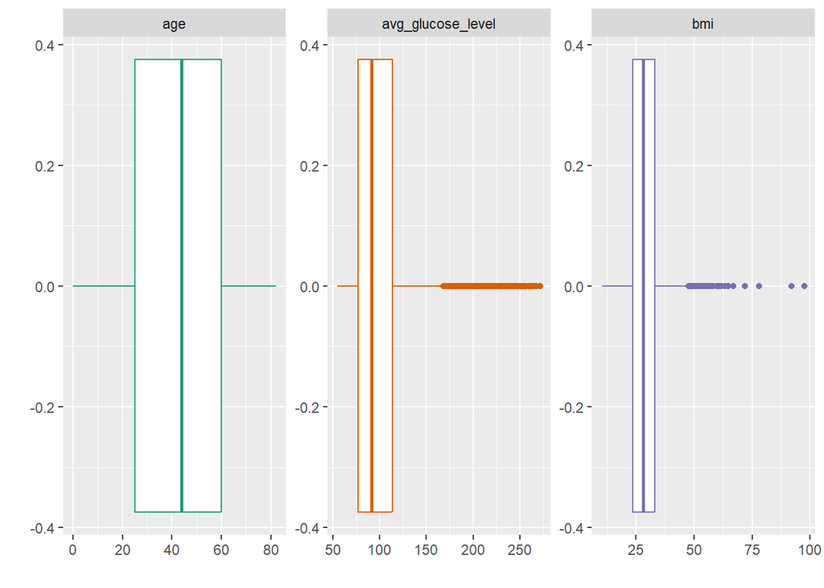

```r
library(RColorBrewer)
library(ggplot2)

boxes <- cleaned_data %>%
  select("age", "avg_glucose_level", "bmi") %>%
  pivot_longer(everything(),
               names_to = "item",
               values_to = "scores") %>%
  ggplot(aes(x = scores, color = item)) +
  geom_boxplot() +
  labs(y = "", x="") +
  theme(legend.position = "none") +
  facet_wrap(~item,scales = "free")

boxes + scale_color_brewer(palette="Dark2")
```

## Категориальные переменные

1. Сделайте подходящие визуализации категориальных переменных. Обоснуйте, почему выбрали именно этот тип.

Имеется достаточно мало категорий каждой переменной (в основном - 2 штуки), поэтому наилучшим образом подходит geom_bar.

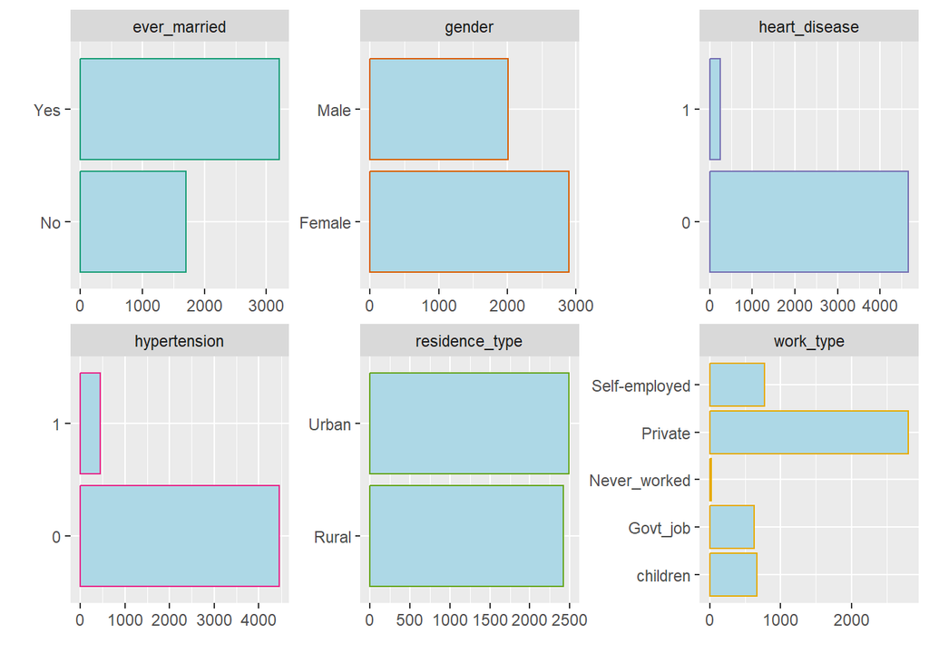

```r
bars <- cleaned_data %>%
  select("gender", "hypertension", "heart_disease", "ever_married", "work_type", "residence_type") %>%
  pivot_longer(everything(),
               names_to = "item",
               values_to = "scores") %>%
  ggplot(aes(x = scores, color = item)) +
  geom_bar(fill = "lightblue") +
  labs(y = "", x="") +
  theme(legend.position = "none") +
  facet_wrap(~item,scales = "free") +
  coord_flip()

bars + scale_color_brewer(palette="Dark2")
```

# Статистические оценки

## Проверка на нормальность

1. Оцените каждую переменную на соответствие нормальному распределению с помощью теста Шапиро-Уилка. Какие из переменных являются нормальными и как как вы это поняли?

```r
shapiro.test(cleaned_data[['age']])
```

```
##
##  Shapiro-Wilk normality test
##
## data:  cleaned_data[["age"]]
## W = 0.96865, p-value < 2.2e-16
```

```r
shapiro.test(cleaned_data[['avg_glucose_level']])
```

```
##
##  Shapiro-Wilk normality test
##
## data:  cleaned_data[["avg_glucose_level"]]
## W = 0.80568, p-value < 2.2e-16
```

```r
shapiro.test(cleaned_data[['bmi']])
```

```
##
##  Shapiro-Wilk normality test
##
## data:  cleaned_data[["bmi"]]
## W = 0.95357, p-value < 2.2e-16
```

Тест Шапиро-Уилка показывает отсутствие нормальности распределения age, avg_glucose_level и bmi: Так как p-value меньше, чем уровень значимости 0.05 (< 2e-16), у нас есть основания отвергнуть нулевую гипотезу о том, данные распределены нормально.

2. Постройте для каждой количественной переменной QQ-плот. Отличаются ли выводы от теста Шапиро-Уилка? Какой метод вы бы предпочли и почему?

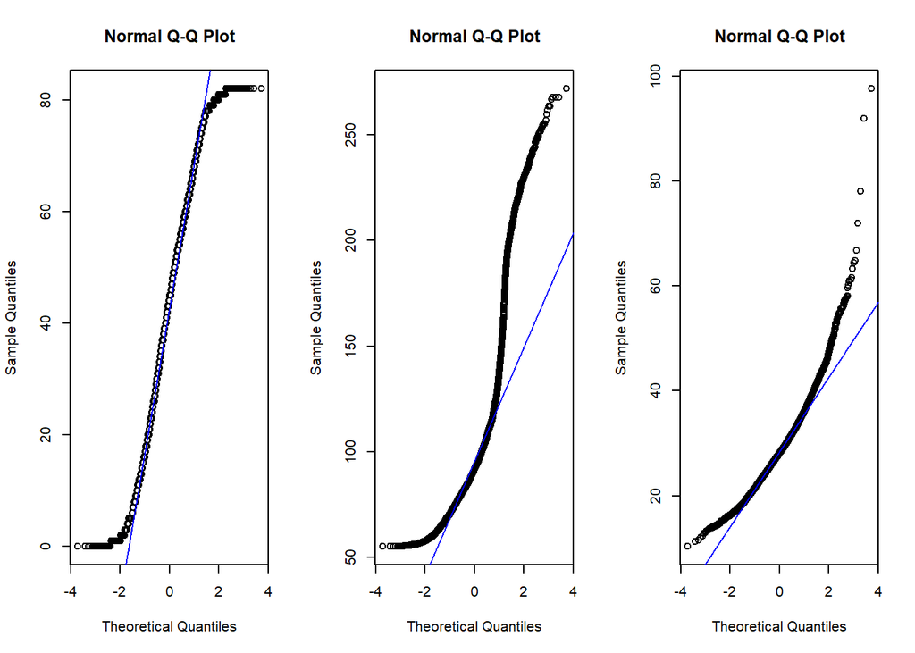

```r
par(mfrow = c(1,3))

qqnorm(cleaned_data[['age']])
qqline(cleaned_data[['age']], col = "blue") #добавление теоретической линии, соответствующей нормальному распределению

qqnorm(cleaned_data[['avg_glucose_level']])
qqline(cleaned_data[['avg_glucose_level']], col = "blue")

qqnorm(cleaned_data[['bmi']])
qqline(cleaned_data[['bmi']], col = "blue")
```

Во всех трех случаях точки, построенные по нашим данным, отклоняются от теоретической линии, соответствующей нормальному распределению, то есть данные не распределены нормально. Это сходится с результатами теста Шапиро-Уилка.

3. Ниже напишите, какие ещё методы проверки на нормальность вы знаете и какие у них есть ограничения.

Во-первых, можно построить обычную гистограмму и визуально оценить, напоминает ли распределение нормальное.

Во-вторых, можно провести тест Колмогорова-Смирнова, но он предназначен только для непрерывных данных и чувствителен к длине выборки (размер выборки не менее 50, при 25-50 можно использовать с поправкой Большева).

В-третьих, можно провести тест Андерсона-Дарлинга - он также чувствителен к длине выборки, но в меньшей степени (размер выборки не менее 8).

## Сравнение групп

1. Сравните группы (переменная **stroke**) по каждой переменной (как количественной, так и категориальной). Для каждой переменной выберите нужный критерий и кратко обоснуйте его выбор в комментариях.

Начнем с количественных переменных - age, avg_glucose_level и bmi. Так как распределение не является нормальным, используем не z.test, а t.test.

```r
stroke1_age <- cleaned_data[cleaned_data$stroke == "1", ]$age
stroke0_age <- cleaned_data[cleaned_data$stroke == "0", ]$age
t.test(x = stroke1_age, y = stroke0_age, alternative = "two.sided")
```

```
##
##  Welch Two Sample t-test
##
## data:  stroke1_age and stroke0_age
## t = 28.296, df = 271.81, p-value < 2.2e-16
## alternative hypothesis: true difference in means is not equal to 0
## 95 percent confidence interval:
##  24.15457 27.76712
## sample estimates:
## mean of x mean of y
##  67.71292  41.75207
```

```r
stroke1_avg_glucose_level <- cleaned_data[cleaned_data$stroke == "1", ]$avg_glucose_level
stroke0_avg_glucose_level <- cleaned_data[cleaned_data$stroke == "0", ]$avg_glucose_level
t.test(x = stroke1_avg_glucose_level, y = stroke0_avg_glucose_level, alternative = "two.sided")
```

```
##
##  Welch Two Sample t-test
##
## data:  stroke1_avg_glucose_level and stroke0_avg_glucose_level
## t = 7.0034, df = 216.86, p-value = 3.093e-11
## alternative hypothesis: true difference in means is not equal to 0
## 95 percent confidence interval:
##  21.97102 39.18102
## sample estimates:
## mean of x mean of y
##  134.5714  103.9954
```

```r
stroke1_bmi <- cleaned_data[cleaned_data$stroke == "1", ]$bmi
stroke0_bmi <- cleaned_data[cleaned_data$stroke == "0", ]$bmi
t.test(x = stroke1_bmi, y = stroke0_bmi, alternative = "two.sided")
```

```
##
##  Welch Two Sample t-test
##
## data:  stroke1_bmi and stroke0_bmi
## t = 3.6374, df = 237.84, p-value = 0.0003377
## alternative hypothesis: true difference in means is not equal to 0
## 95 percent confidence interval:
##  0.7549231 2.5387991
## sample estimates:
## mean of x mean of y
##  30.47129  28.82443
```

Для age: Так как p-value меньше, чем уровень значимости 0.05 (< 2e-16), у нас есть основания отвергнуть нулевую гипотезу о том, что реальное различие в средних равно 0, и принять альтернативную гипотезу о том, что реальное различие в среднем возрасте между субъектами, испытавшими удар, и не испытавшими удар, не равно 0. При этом у испытавших удар средний возраст больше.

Далее проанализируем категориальные переменные. Так как количество наблюдений в каждой клетке сводных таблиц ниже больше 5, можно применить тест хи-квадрат, а не точный тест Фишера.

```r
print("gender")
```

```
## [1] "gender"
```

```r
d1 <- table(cleaned_data$stroke, cleaned_data$gender)
d1
```

```
##
##     Female Male
##   0   2777 1922
##   1    120   89
```

```r
chisq.test(d1)
```

```
##
##  Pearson's Chi-squared test with Yates' continuity correction
##
## data:  d1
## X-squared = 0.16955, df = 1, p-value = 0.6805
```

```r
print("hypertension")
```

```
## [1] "hypertension"
```

```r
d2 <- table(cleaned_data$stroke, cleaned_data$hypertension)
d2
```

```
##
##        0    1
##   0 4308  391
##   1  149   60
```

```r
chisq.test(d2)
```

```
##
##  Pearson's Chi-squared test with Yates' continuity correction
##
## data:  d2
## X-squared = 97.239, df = 1, p-value < 2.2e-16
```

```r
print("heart_disease")
```

```
## [1] "heart_disease"
```

```r
d3 <- table(cleaned_data$stroke, cleaned_data$heart_disease)
d3
```

```
##
##        0    1
##   0 4496  203
##   1  169   40
```

```r
chisq.test(d3)
```

```
##
##  Pearson's Chi-squared test with Yates' continuity correction
##
## data:  d3
## X-squared = 90.25, df = 1, p-value < 2.2e-16
```

```r
print("ever_married")
```

```
## [1] "ever_married"
```

```r
d4 <- table(cleaned_data$stroke, cleaned_data$ever_married)
d4
```

```
##
##       No  Yes
##   0 1681 3018
##   1   23  186
```

```r
chisq.test(d4)
```

```
##
##  Pearson's Chi-squared test with Yates' continuity correction
##
## data:  d4
## X-squared = 53.076, df = 1, p-value = 3.209e-13
```

```r
print("residence_type")
```

```
## [1] "residence_type"
```

```r
d6 <- table(cleaned_data$stroke, cleaned_data$residence_type)
d6
```

```
##
##     Rural Urban
##   0  2318  2381
##   1   100   109
```

```r
chisq.test(d6)
```

```
##
##  Pearson's Chi-squared test with Yates' continuity correction
##
## data:  d6
## X-squared = 0.12169, df = 1, p-value = 0.7272
```

Для gender, residence_type: Так как p-value больше, чем уровень значимости 0.05, у нас нет основания отвергнуть нулевую гипотезу о том, что факторы наличие удара и пол, наличие удара и тип местожительства независимы.

Для hypertension, heart_disease, ever_married: Так как p-value меньше, чем уровень значимости 0.05, у нас есть основания отвергнуть нулевую гипотезу о том, что факторы наличие удара и гипертензии, наличие удара и болезни сердца, наличие удара и факт женитьбы независимы.

В случае типа работы в некоторых ячейках сводной таблицы есть значение меньше 5:

```r
print("work_type")
```

```
## [1] "work_type"
```

```r
d5 <- table(cleaned_data$stroke, cleaned_data$work_type)
d5
```

```
##
##     children Govt_job Never_worked Private Self-employed
##   0      670      602           22    2683           722
##   1        1       28            0     127            53
```

```r
fisher.test(d5, workspace=2e9)
```

```
##
##  Fisher's Exact Test for Count Data
##
## data:  d5
## p-value = 4.739e-12
## alternative hypothesis: two.sided
```

# Далее идут **необязательные** дополнительные задания, которые могут принести вам дополнительные баллы в том числе в случае ошибок в предыдущих

## Корреляционный анализ

1. Создайте корреляционную матрицу с визуализацией и поправкой на множественные сравнения. Объясните, когда лучше использовать корреляционные матрицы и в чём минусы и плюсы корреляционных исследований.

Применим непараметрический метод Спирмена, а не параметрический метод Пирсона, так как данные не распределены нормально:

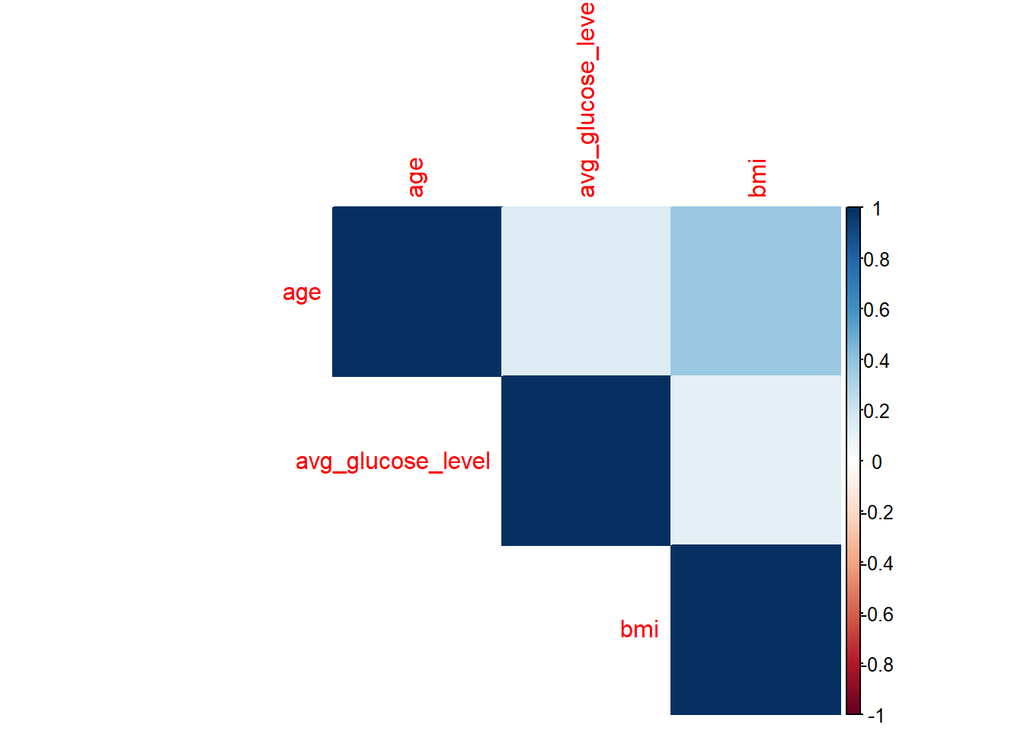

```r
library(corrplot)
cors <- cor(cleaned_data[,c("age", "avg_glucose_level", "bmi")], method = "spearman")
corrplot(cors, type = "upper", method="color")
```

Корреляция - это статистическая взаимосвязь двух и более величин, при которой изменение одной или нескольких из этих величин сопутствует систематическому изменению значений другой или других величин. Корреляционный анализ позволяет лишь установить факт наличия связи между переменными, но не может доказать причинно-следственной зависимости. Полученные значения - сила корреляционной связи. Особенно неудобно то, что многие методы (в т.ч. метод Пирсона) улавливают только линейные связи. Кроме того, его обычно применяют для количественных данных. Однако, корреляционный анализ часто используют в разведочном анализе (например, до построения модели регрессии, чтобы заранее представлять, какие факторы могут оказаться значимыми).

## Моделирование

1. Постройте регрессионную модель для переменной **stroke**. Опишите процесс построения

Так как stroke является категориальной переменной, необходимо применить не лийнейную, а бинарную логистическую регрессию.

```r
model2 <- glm(stroke ~ gender + age + hypertension + heart_disease + ever_married + work_type + residence_type + avg_glucose_level + bmi, data = cleaned_data, family = "binomial")
summary(model2)
```

```
##
## Call:
## glm(formula = stroke ~ gender + age + hypertension + heart_disease +
##     ever_married + work_type + residence_type + avg_glucose_level +
##     bmi, family = "binomial", data = cleaned_data)
##
## Coefficients:
##                          Estimate Std. Error z value Pr(>|z|)
## (Intercept)             -7.592168   1.040459  -7.297 2.94e-13 ***
## genderMale               0.005306   0.152809   0.035 0.972298
## age                      0.071867   0.006215  11.564  < 2e-16 ***
## hypertension1            0.544799   0.174181   3.128 0.001761 **
## heart_disease1           0.385502   0.206167   1.870 0.061504 .
## ever_marriedYes         -0.105190   0.246855  -0.426 0.670020
## work_typeGovt_job       -0.386126   1.100806  -0.351 0.725763
## work_typeNever_worked   -9.713622 309.194152  -0.031 0.974938
## work_typePrivate        -0.229158   1.087294  -0.211 0.833074
## work_typeSelf-employed  -0.658006   1.106314  -0.595 0.551995
## residence_typeUrban      0.021736   0.149542   0.145 0.884435
## avg_glucose_level        0.004664   0.001293   3.606 0.000311 ***
## bmi                      0.003762   0.011831   0.318 0.750509
## ---
## Signif. codes:  0 '***' 0.001 '**' 0.01 '*' 0.05 '.' 0.1 ' ' 1
##
## (Dispersion parameter for binomial family taken to be 1)
##
##     Null deviance: 1728.3  on 4907  degrees of freedom
## Residual deviance: 1368.4  on 4895  degrees of freedom
## AIC: 1394.4
##
## Number of Fisher Scoring iterations: 14
```

**Интепретация:**

```r
cleaned_data$probabilities2 <- predict(model2, type = "response", newdata= cleaned_data)
summary(cleaned_data$probabilities2)
```

```
##      Min.   1st Qu.    Median      Mean   3rd Qu.      Max.
## 0.0000001 0.0037995 0.0147683 0.0425835 0.0503064 0.5319151
```

```r
cleaned_data$classification2 <- ifelse(cleaned_data$probabilities2 > 0.5, 1, 0)
accuracy <- mean(cleaned_data$classification2 == cleaned_data$stroke)
accuracy
```

```
## [1] 0.9574165
```

Точность модели = 95.74%, то есть достаточно высока.

**Проверим допущения бинарной логистической регрессии:**

Вспомним допущения линейной: 1. Линейная взаимосвязь между переменными. - не требуется. Но требуется линейная взаимосвязь между независимыми переменными и логитом результата! 2. Нормальное распределение остатков и ошибки не носят систематического характера - не требуется. 3. Гомоскедастичность - не требуется. 4. Ошибки некоррелированы: 𝐶𝑜𝑣(𝜖𝑖,𝜖𝑗) = 0 (отсутствие автокорреляции) - требуется! 5. Отсутствие мультиколлениарности (vif) - требуется! 6. Нормальное распределение переменных - не требуется.

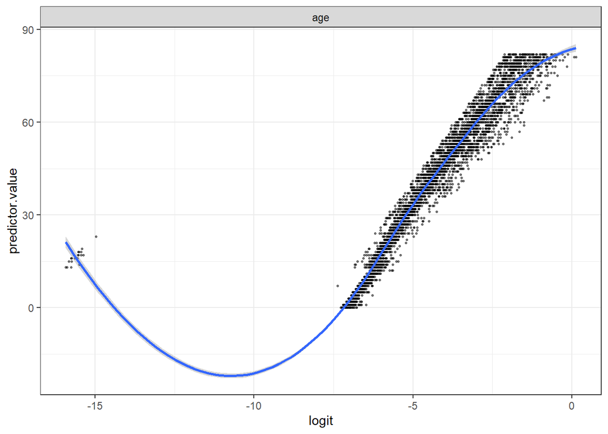

```r
mycleaned_data <- select(cleaned_data, age, probabilities2)
mycleaned_data <- mycleaned_data  %>%
  mutate(logit = log(probabilities2/(1-probabilities2))) %>%
  select(-probabilities2) %>%
  gather(key = "predictors", value = "predictor.value", -logit)

ggplot(mycleaned_data, aes(logit, predictor.value))+
  geom_point(size = 0.5, alpha = 0.5) +
  geom_smooth(method = "loess") +
  theme_bw() +
  facet_wrap(~predictors, scales = "free_y")
```

4. Однако, можно говорить о том, что есть положительная автокорреляция ошибок, что видно по тесту Дарбна-Уотсона (DW < 2):

```r
lmtest::dwtest(model2)
```

```
##
##  Durbin-Watson test
##
## data:  model2
## DW = 0.48698, p-value < 2.2e-16
## alternative hypothesis: true autocorrelation is greater than 0
```

5. Можно говорить об отсутствии мультиколлинеарности, что видно по тому, что все значения меньше 5 и близки к 1:

```r
library(car)
vif(model2)
```

```
##                       GVIF Df GVIF^(1/(2*Df))
## gender            1.025166  1        1.012505
## age               1.339847  1        1.157518
## hypertension      1.055893  1        1.027566
## heart_disease     1.081960  1        1.040173
## ever_married      1.072080  1        1.035413
## work_type         1.256147  4        1.028916
## residence_type    1.004056  1        1.002026
## avg_glucose_level 1.112038  1        1.054532
## bmi               1.114633  1        1.055762
```

Таким образом, одно из допущений бинарной логистической регрессии не выполняется, однако данный анализ можно использовать для планирования дальнейших исследований.